# Web Exercise 4

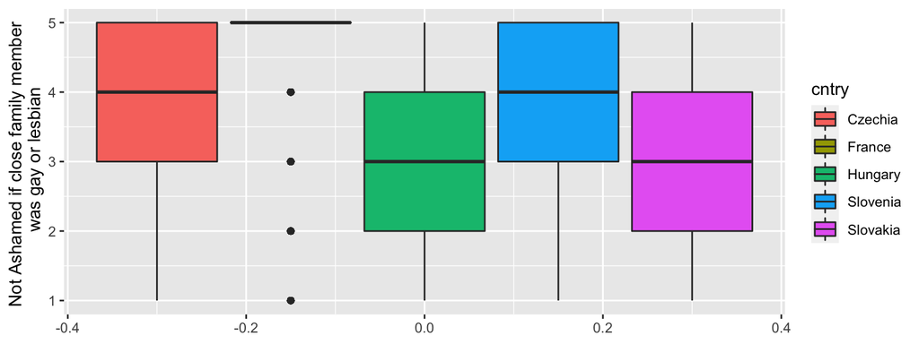

```r
ggplot(data = ESS) +
  geom_boxplot(aes(y = as.numeric(hmsfmlsh), fill = cntry, weight = pspwght)) +
  labs(y = "Not Ashamed if close family member \n was gay or lesbian")
```

4. Find an alternative to using boxplots.

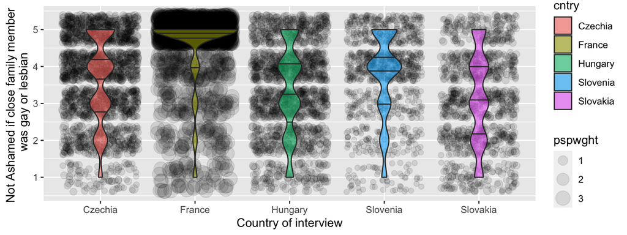

```r
ggplot(data = ESS, mapping = aes(y = as.numeric(hmsfmlsh), x = cntry)) +
  geom_jitter(alpha = 0.1, aes(size = pspwght)) +
  geom_violin(mapping = aes(fill = cntry, weight = pspwght),
              alpha = 0.6, draw_quantiles = c(0.25, 0.5, 0.75)) +
  labs(y = "Not Ashamed if close family member \n was gay or lesbian",
       x = "Country of interview")
```

5. Remember that the years of education have some rather low and large values. Recode all values smaller than 10 years of education to missing. Also Recode all years of education larger than 20 to 20. Visualize how that changes the association between `hmsfmlsh` and years of education. Does it change the main conclusion/insight of that figure?

```r
ESS <- mutate(ESS,
              eduyrs_rec = case_when(
                eduyrs < 10 ~ as.numeric(NA), # Edu-years smaller 10 ~ Missing
                eduyrs > 20 ~ 20, # Edu-years larger 20 ~ 20
                TRUE ~ eduyrs) # Leave all others as is.
)
```

The old one:

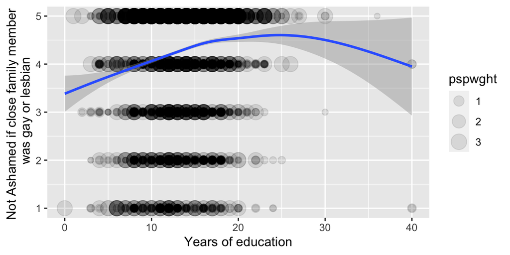

```r
ggplot(data = ESS, mapping = aes(y = as.numeric(hmsfmlsh), x = eduyrs, weight = pspwght)) +
  geom_point(aes(size = pspwght), alpha = 0.1) +
  geom_smooth() +
  labs(y = "Not Ashamed if close family member \n was gay or lesbian",
       x = "Years of education")
```

The new one:

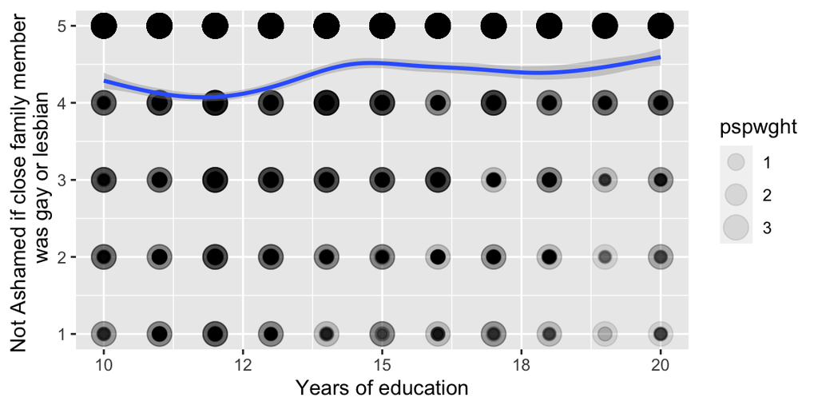

```r
ggplot(data = ESS, mapping = aes(y = as.numeric(hmsfmlsh), x = eduyrs_rec, weight = pspwght)) +
  geom_point(aes(size = pspwght), alpha = 0.1) +
  geom_smooth() +
  labs(y = "Not Ashamed if close family member \n was gay or lesbian",
       x = "Years of education")
```